# Research and Development Performance in Various Countries

April 24, 2016

## Introduction

- Research & development (R&D) can increase the productivity of a nation.
- Personally became aware of the lack of R&D jobs available in manufacturing when finishing PhD.
- Personally wanted to understand how this is affecting the country.
- Understanding how this is changing is important to policy makers, economists, and researchers.

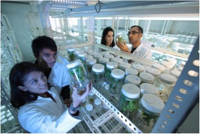

## World development indicators dataset from World Bank

- Statistics on up to 247 countries and regions on 1,344 development indicators
- Yearly indicators as early as 1960 to 2014
- Countries of interest : China, Euro Union, India, Japan, Korea, Russia, USA
- Easy to use:

  ```
  filter(indicators, IndicatorCode == indicatorCode) %>%
  filter(CountryCode %in% countries)
  ```

## Input: R&D expenditure as % of GDP

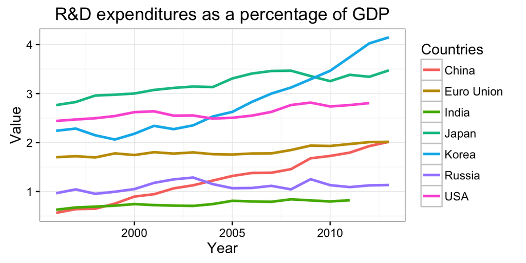

- Korea and China rapidly increasing.
- Japan and USA steady and high.

## R&D output: Journal publications

- Mostly an academic measure.
- Measure of quantity not quality.

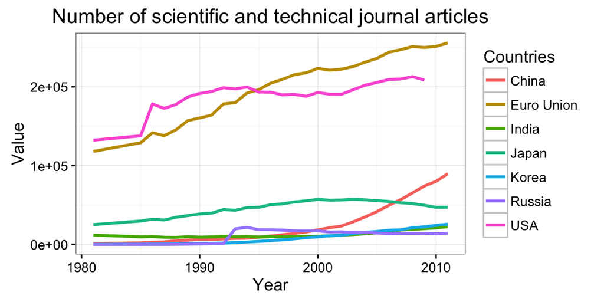

- Euro Union and USA publish a high amount. Euro Union increasing.
- Japan on decline.
- China rapidly rising.

## R&D output: Patent applications

- Mostly an industrial measure.
- Measure of quantity not quality.

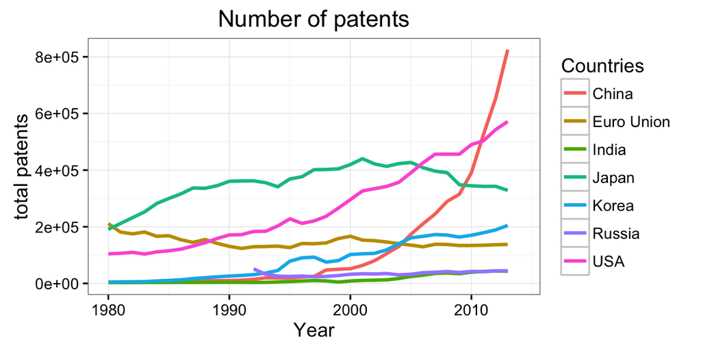

- China increasing rapidly. USA also high.

## Output: Trademark applications

- Software mostly not protected by patents

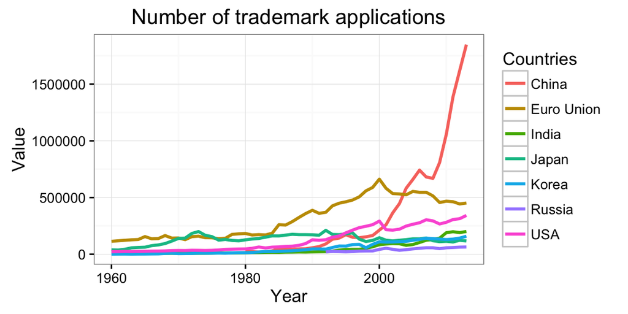

- China rapidly increasing.
- USA also increasing.

## Number of Researchers in R&D

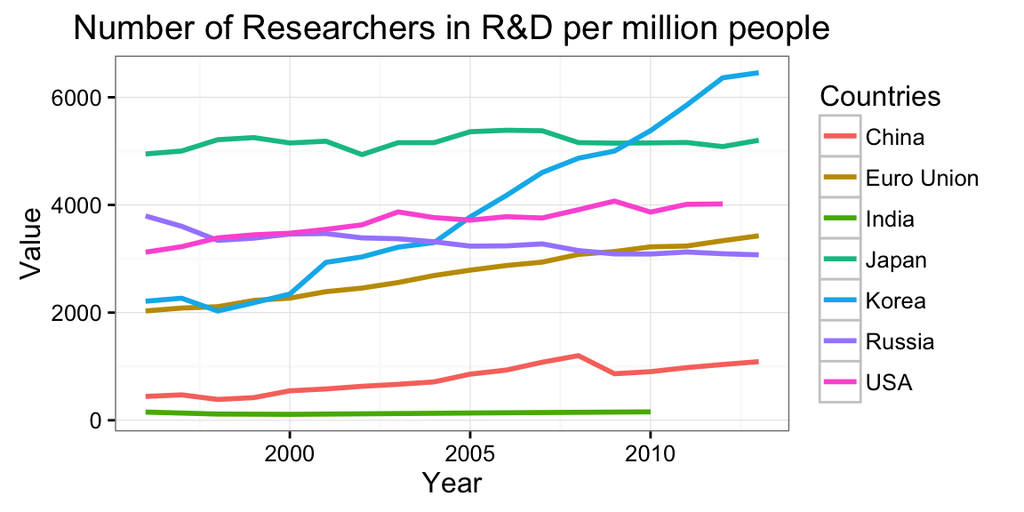

## Value added manufacturing

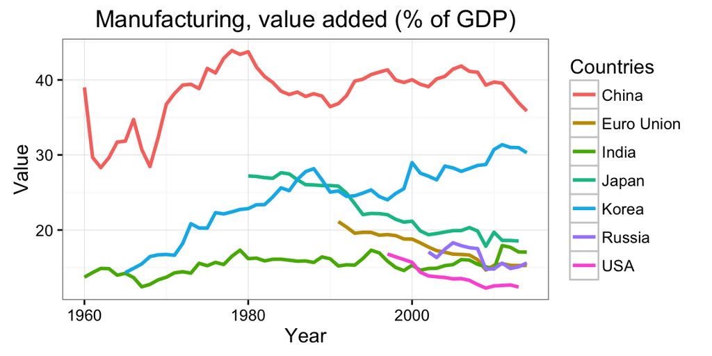

## Conclusions

- China’s R&D expenditure and output rapidly increasing.
- USA and EU research are increasing while manufacturing continues to drop. This could explain why there are a lack of research jobs in the USA.
- Future work:
  - Correlate economic performance with R&D.
  - Measure quality of research